# NHTSA Analysis

Author

Patrick Torralba

# Set-up

## Library

```r
library(tidyverse)
library(kableExtra)
library(sf)
library(rnaturalearth)
library(scales) ## add commas
library(gtsummary) ## needed for tbl_regression
```

## Load Data

```r
df_v2 <- read.csv("Exports/df_v2.csv")
```

## Data Cleaning

We want to remove NA geographic values and change “location” to a factor. “location” has urban set as the reference level.

I also set the following restrictions:

- Restrict to persons who died
- Restrict to light vehicles (see below)
- Restrict to driver or occupant in car
- Restrict to private vehicle below

```r
df_v2 <- df_v2 %>%
  filter(!is.na(location),
           INJ_SEV == 4, ## dead people only
           BODY_TYP %in% 1:8 | BODY_TYP == 17 | ## passenger cars
           BODY_TYP %in% 14:16 | BODY_TYP == 19 | ## SUVS
           BODY_TYP == 20 | ## minivans
           BODY_TYP %in% 30:39, ## pickup trucks
           A_PTYPE %in% 1:2, ## driver or occupant in car
           SPEC_USE == 0) %>%
  mutate(location = fct_relevel(as.factor(location),"Urban"))
```

# Data Analysis & Visualization

## Rural vs Urban Fatality Aggregation

```r
rur_urb_agg <- df_v2 %>%
  group_by(YEAR, location) %>%
  summarize(
    total_persons = sum(PER_NO),
    total_fatals = sum(FATALS.x))
```

## Rural vs Urban Fatality Time-series

Figure 1: Rural vs Urban Fatality Time-series

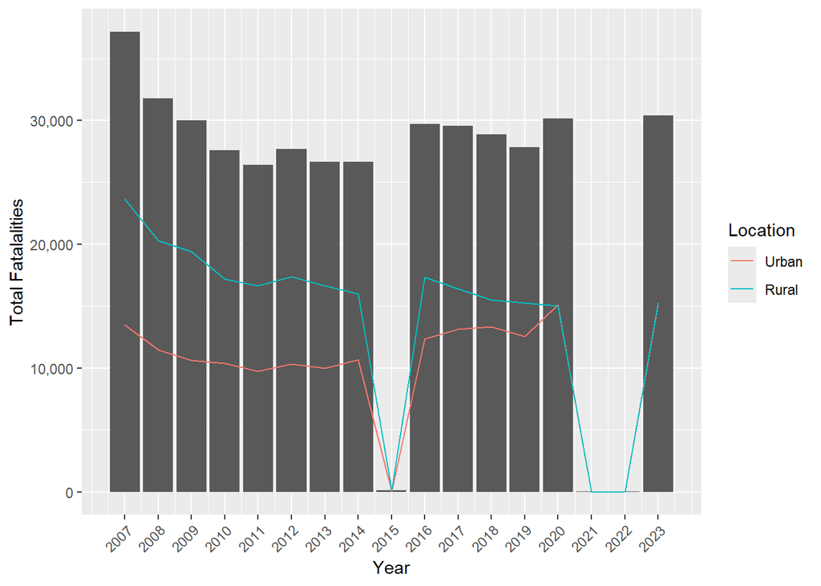

```r
ggplot(rur_urb_agg, aes(x = YEAR, y = total_fatals)) +
  geom_col() +
  geom_line(aes(color = location, group = location)) +
scale_x_continuous(breaks = seq(min(rur_urb_agg$YEAR), max(rur_urb_agg$YEAR), by = 1)) +
scale_y_continuous(labels = scales::label_comma()) +
  labs(
    x = "Year",
    y = "Total Fatalalities",
    color = "Location"
  ) +
  theme(axis.text.x = element_text(angle = 45, vjust = 1, hjust = 1))
```

## Rural vs Urban Fatality Table

```r
rur_urb_agg %>%
  select(-total_persons) %>%
  mutate(total_fatals = scales::comma(total_fatals)) %>%
kable(format = "html",
      col.names = c("Year","Location", "Total Fatals"),
      align = "c") %>%
  kable_styling(bootstrap_options = c("striped", "hover", "condensed"))
```

Table 1: Rural vs Urban Fatalities

| Year | Location | Total Fatals |
| --- | --- | --- |
| 2007 | Urban | 13,507 |
| 2007 | Rural | 23,648 |
| 2008 | Urban | 11,482 |
| 2008 | Rural | 20,299 |
| 2009 | Urban | 10,628 |
| 2009 | Rural | 19,391 |
| 2010 | Urban | 10,362 |
| 2010 | Rural | 17,206 |
| 2011 | Urban | 9,731 |
| 2011 | Rural | 16,661 |
| 2012 | Urban | 10,321 |
| 2012 | Rural | 17,362 |
| 2013 | Urban | 9,992 |
| 2013 | Rural | 16,654 |
| 2014 | Urban | 10,684 |
| 2014 | Rural | 15,985 |
| 2015 | Urban | 38 |
| 2015 | Rural | 114 |
| 2016 | Urban | 12,362 |
| 2016 | Rural | 17,353 |
| 2017 | Urban | 13,147 |
| 2017 | Rural | 16,386 |
| 2018 | Urban | 13,336 |
| 2018 | Rural | 15,518 |
| 2019 | Urban | 12,571 |
| 2019 | Rural | 15,260 |
| 2020 | Urban | 15,109 |
| 2020 | Rural | 15,028 |
| 2021 | Urban | 10 |
| 2021 | Rural | 1 |
| 2022 | Urban | 18 |
| 2022 | Rural | 30 |
| 2023 | Urban | 15,113 |
| 2023 | Rural | 15,262 |

# Poisson Regression Modeling

We use a poisson regression because we want to calculate the rate probability over a fixed amount of time (e.g fatality count over 1 year).

## Unadjusted Model

```r
model1 <- glm(total_fatals ~ location,
                 data = rur_urb_agg,
                 family = poisson(link = "log"))

model1
```

```
Call:  glm(formula = total_fatals ~ location, family = poisson(link = "log"),
    data = rur_urb_agg)

Coefficients:
  (Intercept)  locationRural
       9.2009         0.3632

Degrees of Freedom: 33 Total (i.e. Null);  32 Residual
Null Deviance:      177600
Residual Deviance: 164300   AIC: 164600
```

The unadjusted model only accounts for the total fatalities affected by location.

```r
model1 %>%
  tbl_regression(
    intercept = FALSE,
    exponentiate = TRUE)
```

Table 2: Unadjusted Fatality Model [Exponent Form]

| **Characteristic** | **IRR** | **95% CI** | **p-value** |
| --- | --- | --- | --- |
| location |  |  |  |
| Urban | — | — |  |
| Rural | 1.44 | 1.43, 1.45 | <0.001 |

Abbreviations: CI = Confidence Interval, IRR = Incidence Rate Ratio

## Quasi-Poisson Regression Model for Overdispersion

Before proceeding further with these results, we must first test for overdispersion by reviewing the ratio of the residual deviance to its degree of freedoms. If the model ratio is extremely greater than 1 then that is a sign of overdispersion.

```r
model_ratio <- (model1$deviance / model1$df.residual)

model_ratio
```

```
[1] 5133.268
```

```r
model_ratio > 10
```

```
[1] TRUE
```

Since we verified that this model is overdispersed, we now must deal with it using a quasi-poisson regression model

```r
model1.qp <- glm(total_fatals ~ location,
                 data = rur_urb_agg,
                 family = quasipoisson(link = "log"))

model1.qp
```

```
Call:  glm(formula = total_fatals ~ location, family = quasipoisson(link = "log"),
    data = rur_urb_agg)

Coefficients:
  (Intercept)  locationRural
       9.2009         0.3632

Degrees of Freedom: 33 Total (i.e. Null);  32 Residual
Null Deviance:      177600
Residual Deviance: 164300   AIC: NA
```

```r
model1.qp %>%
  tbl_regression(
    exponentiate = TRUE,
    label = (location ~ "Location")
  )
```

Table 3: Quasi-poisson Regression Model

| **Characteristic** | **IRR** | **95% CI** | **p-value** |
| --- | --- | --- | --- |
| Location |  |  |  |
| Urban | — | — |  |
| Rural | 1.44 | 1.02, 2.03 | 0.046 |

Abbreviations: CI = Confidence Interval, IRR = Incidence Rate Ratio